# Project_1

Iris

October 19, 2014

This project is designed to assess the historical demography and current rates of gene flow bewteen populations of the Desert night lizard (Xantusia vigilis) in central California. Xantusia vigilis is a small, long-lived lizard that rarely travels beyond the small set of cover objects that make up its territory. Juveniles have a dispersal stage, but rarely move more than 200 meters from their place of birth. Given their life history, we expect to detect low gene flow rates between even relatively geographically close (>10 km of separation) sampling locations.

Despite the very low individual dispersal distances, the species is widespread throughout the southwestern US. At the species’ northern range limit, it has a disjunct population separated from the rest of the range by over 50 km. No genetic work has been done on this population, so it is not know whether the population represents a recent colonization event from the southern range (“South up” working hypothesis) or the remnants of a former northern population that later colonized the more southerly areas of the species’ current range (“North down” working hypothesis). Distinguishing between these two hypotheses will give us information about historical patterns of species diversity in the southwestern US. The “North down” hypothesis could imply that central California was once hospitable to species that are now found in southern California, which could be a broadly interesting biogeographical pattern. Knowing the are of maximal genetic diversity at the northern range limit will also help with conservation prioritization, as genetically diverser populations are more “valuable” to the diversity of a species as a whole that low-diversity populations, and should therefore be prioritized for conservation resources.

To test these hypotheses, we used a restriction enzyme-based high throughput sequencing protocol generate to sequence data from Xantusia vigilis collected from various locations in the northern population. The protocol generates sequences of a large number of single nucleotide polymorphisms, which we use in downstream analyses. Here, I present the results form a subset of 16 of those individuals, taken from 10 collection locations in the north and south of the northern population. These individuals provide a preliminary test for the “north up” and “south down” hypotheses. The collection locations are coded for by a 2-3 letter abbreviation, which I will use throughout the project. They are grouped into two major clusters:

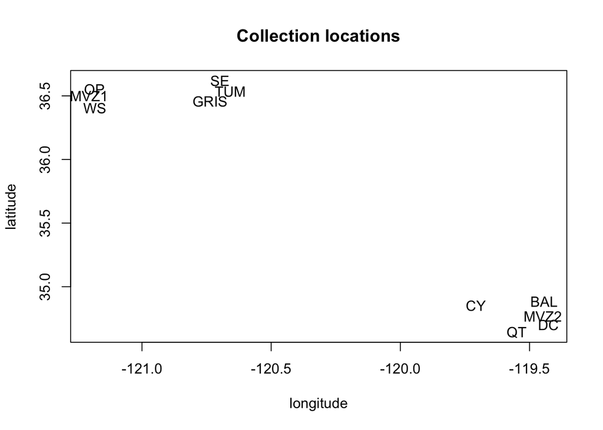

The two hypotheses (“North down” and “South up”) lead to contrasting predictions about the phylogeographical and historical demographic results I should expect from the data. In the “North down”" case, I expect the more northerly populations to be positioned as early branches on a quasi-phylogenetic individual tree created with sequences from each individual. If I were investigating a recent expansion event, I would expect lower observed relative to expected heterozygosity in the southern populations. Regardless of which hypothesis is best supported, this is an old expansion event, so I expect the ratio of observed to expected heterozygosity to have equilibrated in the focal populations. The predictions generated by the “South up” hypothesis are the inverse of the those from the “North up” case. I would expect the southerly populations to be the earliest branches in the tree.

My first step in testing the “South up” and “North down” is to identify the SNPs that conform to the modeling expectations for my downstream applications. Most population genetic statistics expect that all markers 1) meet Hardy-Weinburg expectations, 2) not be in linkage disequilibrium, and, for some applications 3) have no missing data. In a datset with many markers, some SNPs will inevitably be in linkage disequilibrium or out of Hardy-Weinburg equilibrium. Identifying these SNPs and eliminating them from downstream applications is critical to producing reliable results.

I demultiplexed the data and clustered reads first within and then bewteen individuals using the pyRAD pipeline, which prepares data from .fastq files to be read into the alignment programs Muscle and Usearch, and then prepares output files suitable for further analysis. I read the data from 16 aligned individuals into R.

The dataset has 16 individuals and 17291 loci. The first filtering step I applied was to remove all SNPs with more than two states. The reduced dataset is compatible with more R libraries than the original, as many libraries only take SNP data in this format. It also removed SNPs with missing data.

```
## coercing object of mode  numeric  to SnpMatrix
## object has no names - using numeric order for row/column names
```

The reduced dataset has 1611 loci. I used this data set to get some basic summary statistics about the alleles.

The first filtering step I applied was to identify loci that have a significant degree of linkage disequilibrium. I assessed linkage disequilibrium between all pairs of individuals and loci using the “ld” command in snpStats library. Due to our laboratory procedure, which begins by digesting the template DNA using restriction enzymes, our SNPs are not in any biologically relevant order. As such, this procedure identifies pairs of SNPs that are out of linkage equilibrium, rather than providing a linkage map. Further processing will be necessary to identify linkage groups.

I use the “image” function to display a representative group of 100 x 100 loci. The diagonal elements (representing linkage of a SNP with itself) are set to 1. Lighter colors indicate greater linkage diseqilibrium.

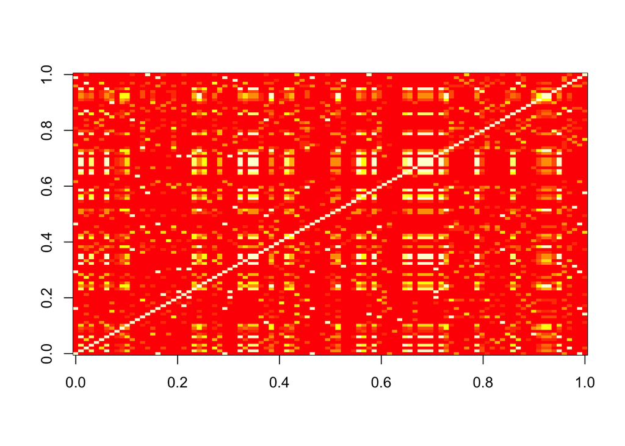

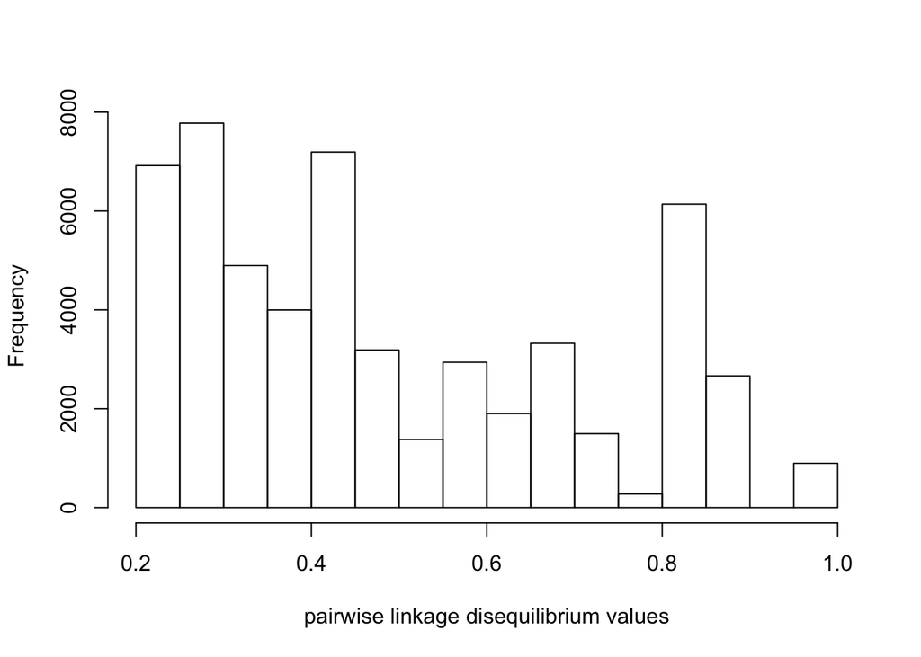

I identified all SNPs that had a pairwise linkage disequilibrium score greater than 0.5. Although still not perfect, this filter should reduce the effect of spurious results due to assumption voilations in downstream analyses if I decide that LD is likely to be a major concern for this dataset.

```
## coercing object of mode  numeric  to SnpMatrix
## object has no names - using numeric order for row/column names
```

```
## coercing object of mode  numeric  to SnpMatrix
## object has no names - using numeric order for row/column names
```

After removing high-linkage disequilibrium SNPs, we have a matrix of 108 SNPs.

We calculated further summary statistics on both the with-ld and without-ld matrices.

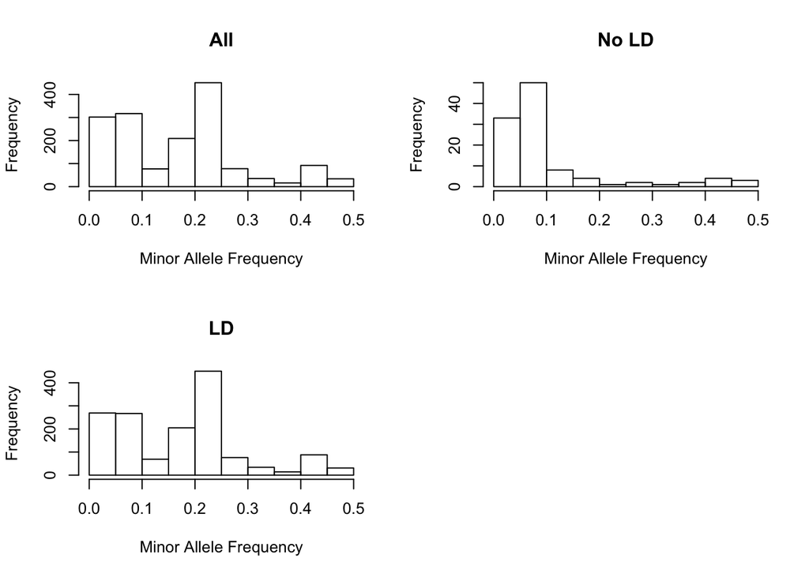

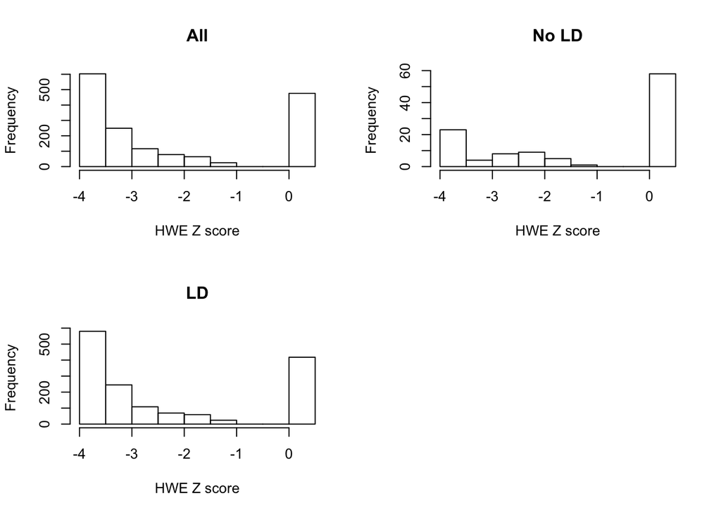

Less than half of the loci (35.0713842 percent) are within two standard deviations of Hardy Weinburg equilibrium. Loci in Hardy Weinburg function as though they are in a population in which neither allelic nor genotypic frequencies change year to year. Although precisely meeting these conditions is unlikely in a natural population, many population genetic statisitics assume Hardy Weinburg equilibrium. However, our dataset is small enough that the deviations could be due to our low number of individuals, rather than Hardy-Weinburg violating processes acting on our sampled populations. The results of further analyses with the assumption of Hardy-Weinburg should be interpreted with caution.

In the LD-removed dataset, 59.2592593 percent of the loci are in Hardy-Weinburg equilibrium. This indicates that linkage equilibrium and Hardy Weinburg equilibrium are related processes in our population.

[figure not shown]

Heterozygosity is low throughout the sample. This indicates that most of the variation in this SNP dataset exists between individuals, rather than within individuals. Biologically, this indicates small population sizes and relatively restricted gene flow between populations. The highest heterozygosity samples are from OP, BAL, and QT. OP is a northern population, so high heterozygosity there supports the “North down” hypothesis. QT and BAL are southern populations, which supports the “South up” hypothesis. When looking at only the low-LD SNPs, the West population (Norther) has both the highest heterozygosity and the greatest standard error. The high-LD SNPs parallel the full dataset. The results from the heterozygosity test don’t conclusively support either hypothesis. However, due to the short dispersal distances and likely long time since colonization, we expect heterozygosity to reflect local population processes rather than colonization history. Further surveys may indicate that OP, BAL, QT and WS have higher population sizes than the other collection locations.

After having worked with the high- and low-LD SNP data sets in parallel with the full dataset, it is clear that linkage disequilibrium plays a large role in the observed distribution of genetic diversity the data. Determining the precise role and hypothesizing about the demographic events that led to the high observed linkage disequilibrium will require a larger dataset. At present, I will proceed with the full dataset for most further analyses.

The first critical analysis for differentiating between the “North down” and “South up” hypotheses is building a tree to see whether the northern populations are nested within the southern populations (“South up”), or vice versa. To build the tree, we used the R packages “adegenet” and “ape.” We first built a pairwise matrix of Nei’s genetic distance between each individual in the dataset using the adegenet package. We used that distance matrix to build a neighbor joining tree with the package “ape.”

```
##
##  Converting data from a STRUCTURE .stru file to a genind object...
```

```
##
##  Replaced 208426 missing values
```

```
##
##  Converting data from a genind to a genpop object...
##
## ...done.
```

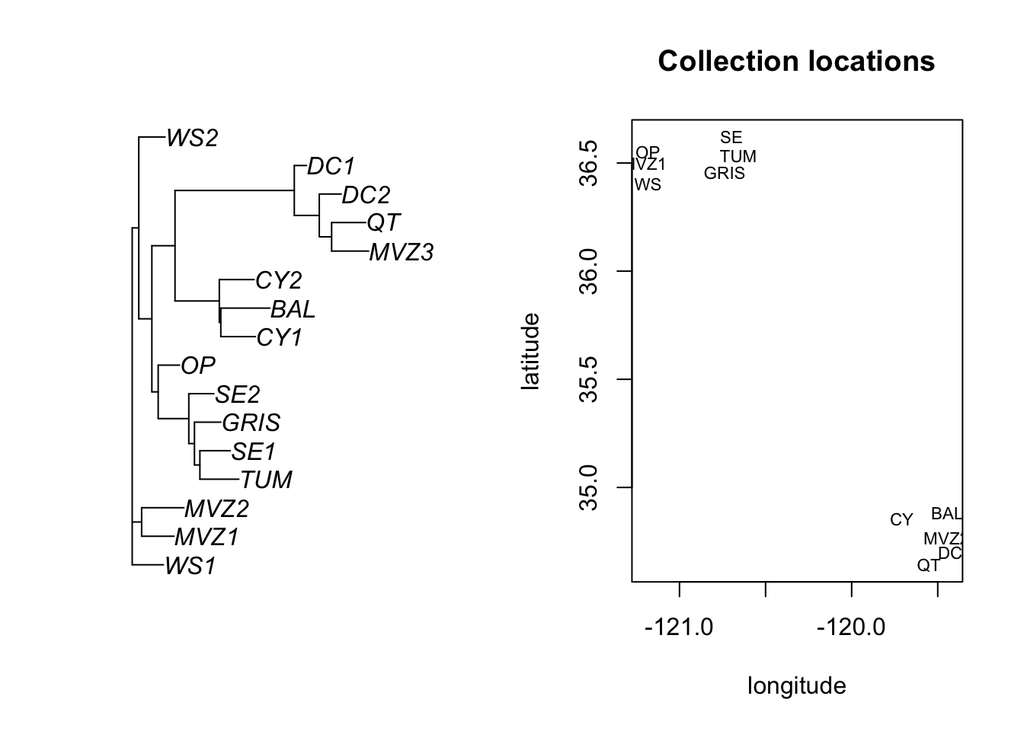

As an independent assessment the genetic clusters in the data, I used a principle components analysis (PCA). This is a method that identifies mutually perpendicular axes of variation in the data, and assigns coordinates to each individual with respect to those axes. Individuals that occur in close proximity to each other in principle coordinate space are considered a genetic group. The method does not assume linkage equilibium or Hardy Weinburg equilibrium, making it ideal for our dataset, which violates both of these assumptions at a large proportion of loci.

To implement this method, I first transform the data into PC-space. After the transformation, I perform k-means clustering at values of k from 2 to 10, which is the number of geographical locations where samples were collected. I chose the optimal k value by determining which k-value has the lowest Bayesian Information Criterion associated with it. By looking at multiple resampled data sets, I observed that the optimal value for the number of PCA axes to retain for analysis was 15, and the k value with the lowest associated BIC was 4. With these clusters, I perform a discriminant analysis of principle components to determine the pairwise distance between each cluster in PC-space.

```
##
##        1 2 3 4
##   WS   0 0 0 2
##   MVZ  0 0 0 2
##   MVZ3 1 0 0 0
##   OP   0 0 0 1
##   DC   2 0 0 0
##   CY   0 0 2 0
##   BAL  0 0 1 0
##   QT   1 0 0 0
##   TUM  0 1 0 0
##   GRIS 0 1 0 0
##   SE   0 2 0 0
```

[figure not shown]

Since I have a large number of loci available, I resampled 100 of them 50 times. Resampling will also speed computation relative to the full dataset. It also generates an empirical quasi-confidence interval, as I can track the pairwise distance in PC-space between all groups at each iteration, and determine the standard error of those pairwise distances. I would consider two groups with a short pairwise mean distance in PC-space but non-overlapping confidence intervals to be more distinct genetically than two groups whose mean is larger but whose standard errors overlap. Calculating a single location based on the full dataset does not provide this type of confidence interval estimate.

To return to a two-axis system, I apply multidimensional scaling with two axes retained to the mean pairwise distance matrix generated from the resampled loci. I plot the loci in MDS-coordinate space. To related the standard error generated by bootstrapping to the new coordinate system, I find SE/mean calculated from the distance matrices. I then find the MDS-space distance and plot “standard error bars” on both sides of the point parallel to the line between the two points.

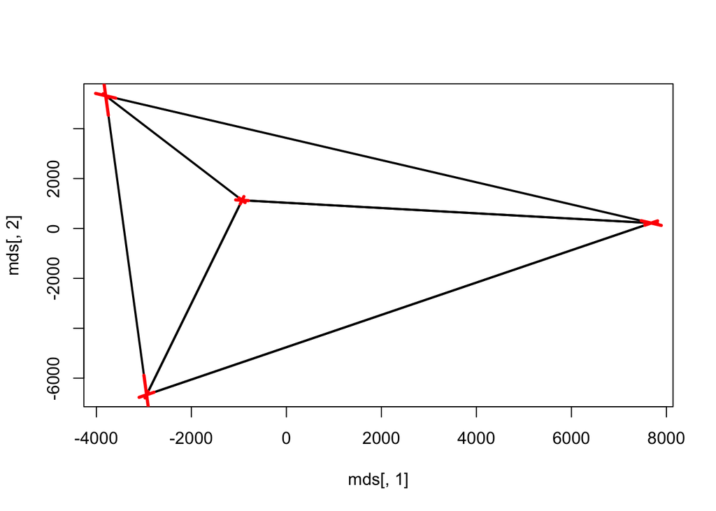

This analysis shows that the groupings are well supported by bootstrapping, indicating that the DAPC clusters reflect demograhic events that affected the entire genome, rather than being determined by strong effects on a few alleles.